# PH390R EDA Final Project

Alexander Rougellis

5/10/2021

# 1. Introduction

I also include a supplementary data set that focuses on drug arrest from the same source that I got the main data set from.

## 1.1 Diving into the Dataset

Now that we have a general idea of what the data set is and its origin, lets dive into the content of the data. This data set contains $644$ observations with $47$ variables. The majority of these variables were of sex and age in the form of `sex_age1_age2` where `sex` was either `m` for male or `f` for female and `age1` and `age2` were a range of ages (i.e. 20-24). In order to make those important variables useful, I separated and collapsed these variables into their own columns. Along with these, I was also given observations for races including White, Black, American Indian, and Asian Pacific Islander. I also relied on the variable that gives the year for every offense and a variable including the name of the offense for the arrest (the data set also included an abbreviation of the offenses, which were not useful since I had the original variable name, so I omitted it).

The supplementary drug arrest data set [1] includes the number of arrests for each drug. This includes drug possession and manufacturing, but for this project, I will focus solely on the variables involving drug possession.

### 1.1.1 Missing data

There was bound to be a few missing variables within such a massive data set. The majority of the missing variables were within the state abbreviation variable. For some reason, every observation within this variable turned out to be a missing value. Looking through the other data sets on the website, this seemed to be a common occurrence and I could not find any information as to why, so sadly I could not use the state variable in my analysis. The rest of the missing variables occurred under a few `sex_age1_age2` variables. But given that sex and age were required to be documented, these missing values just mean there were no arrest for that specific age group for that particular offense. It didn’t make a difference if I removed them or kept them. At some points, R didn’t like that there were missing values and it seemed to confuse the program, so I removed them.

# 2. Analysis

The question I will be asking and figuring out is **What are people most likely to get arrested for?**

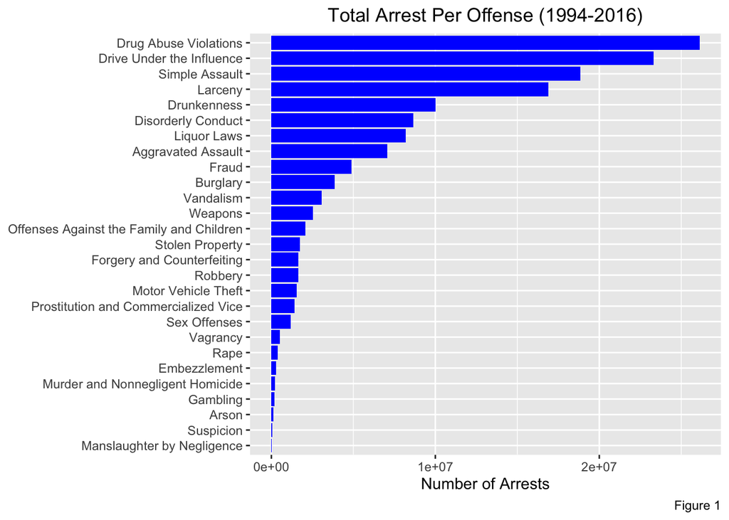

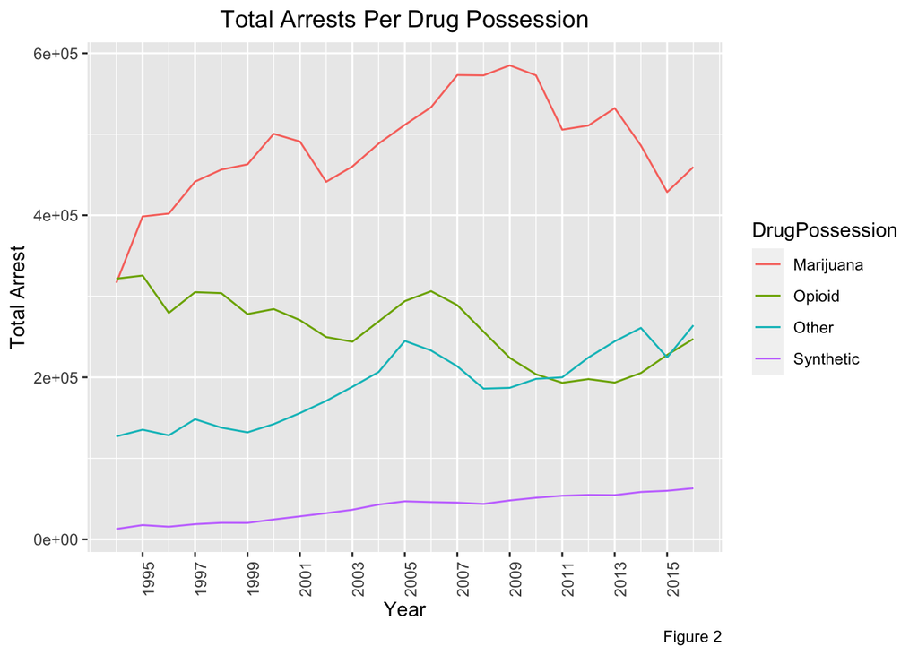

The offense that people are most likely to get arrested for is actually “All Other Offenses” which is defined as state and/or local laws that don’t include traffic laws [2]. I decided not to include this in the figure above as this is not a uniform law across the country. Also, these local and state laws range from being smaller petty crimes to more severe crimes, which is too broad of a spectrum to be included in one variable.

According to *Figure 1*, Drug Abuse Violations is at the top of the list with 26,119,641 arrests over the course of $22$ years. This makes sense, especially after the passing of the Anti-Drug Abuse Act of 1986 [3]. And we can see from *Figure 2*, people who possess marijuana are most likely to get arrested. I would love to see if those numbers drop as more and more states legalize recreational use. We can see the effects of some states legalizing recreational and medical marijuana post 2012 [4] as the overall trend from that point onward seems to be negative. I would also be very interested to see *Figure 2* divided up further by race. When graphing drug arrests per year split by race, there seems to be a negative trend for black people getting arrested over drug related offenses vs that of a positive trend of white people getting arrested for drug related offenses. Maybe this correlates to the overall negative trend of marijuana arrest vs the slight positive trend of opioid, synthetic, and other drug-related arrests.

The question and its answer seem to be simple and straightforward. Yet, the label ‘people’ is very broad and can be broken down even further into categories of race and sex.

## 2.1 Arrests by Sex

The question is now: **Which sex is most likely to be arrested?** Over the course of 22 years the total number of males arrested is 160,141,777 while the total number females arrested is 47,107,275! That is a shocking difference given that women and men make up about the exact same percent of the population.

Now that we know the answer to that question, **Which sex is most likely to be arrested for which offense?** Given that there is a great difference in arrest populations between males arrested and females arrested, I created a graph showing the proportions of arrests.

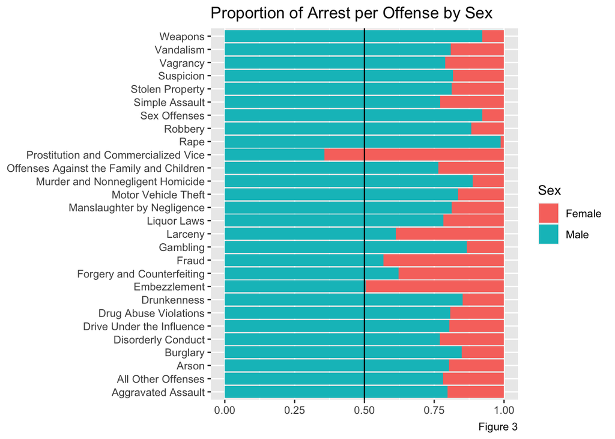

[figure not shown]

Looking at *Figure 3*, it is not shocking that there is a greater proportion of males committing a majority of these offenses (minus that of prostitution which in of itself says a lot). The offenses that have a higher proportion of female arrests than the rest of the offenses seem to involve money (i.e. embezzlement, fraud, forgery, and larceny) while males dominate in more aggressive offenses such as weapons, assault, robbery/theft, rape, murder, etc.

After seeing these results, I wondered which age group, split by sex, is mostly likely to be arrested. According to *Figure 4*, males dominate all ages groups when it comes to arrests. There is a huge spike within the age group of 20-24 (with the age group 18-19 following behind) for both genders. If the data was more detailed, it would show which offense each age group is more likely to get arrested for. My prediction would be that the younger age groups commit more violent and spontaneous offenses (such robbery, assault, etc) while the older age groups commit more complex offenses (such as fraud, forgery, etc).

All the missing values under the `sex_age1_age2` variables come from the older age groups (55+), and consisted only of females.

## 2.2 Arrest by Race

The next question is **Which race is most likely to be arrested?** Sadly, as stated in the introduction, law enforcement agencies participating are not required to document race and ethnicity, so the full picture is not provided. Although, the data given will provide a glimpse of the overall trend. Over the course of 22 years the total number of white people arrested is 141,556,799, total number of black people arrested is 59,541,022, total number of Asian pacific islander arrest is 2,304,537, and total number of American native is 2,826,987. I was interested in learning about the proportion of those who did and did not go to jail for a crime as well as the sentencing for the crime committed as it relates to race to see if it was disproportionate. Unfortunately, this data doesn’t go into that amount of detail so I was unable to explore that.

The next question is **Which race is most likely to be arrested for which offense?** Again, given that there is a great difference in arrest populations between each race, I had to create a graph showing the proportions of arrests.

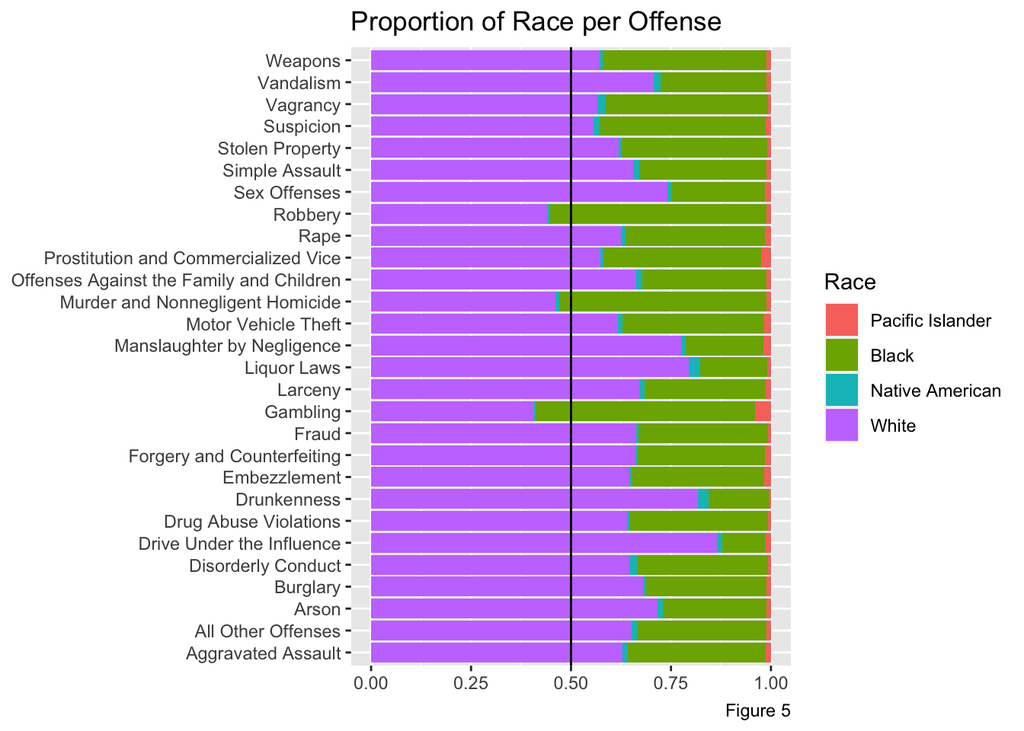

[figure not shown]

Looking at *Figure 5* we can see that overall a greater proportion of white people are to be arrested while a greater proportion of black people are arrested for offenses such as gambling, murder, and robbery. What I find most interesting is the high proportion of offenses committed by Native Americans including alcohol use [5], drunkenness, liquor law arrests, and actions like disorderly conduct and drunk driving. When it comes to the arrest for each age group per race, there are similar results as figure 4 where the majority of arrests occur within the age group of 20-24 for all races.

## 2.3 Bonus Analysis

While all the questions I had relating to “who is likely to get arrested for what” are answered, I am still very curious to see other graphs to better understand the data. Starting off with….

### 2.3.1 Time Graphs

I am curious to see the trend of total arrest over the years.

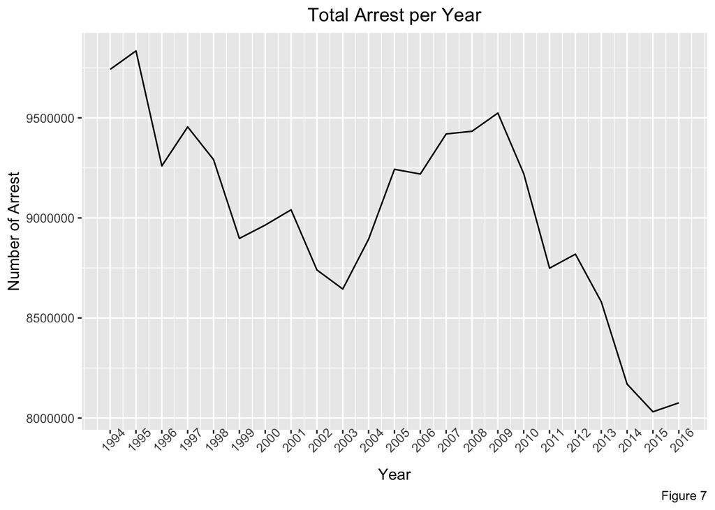

This graph sparked my curiosity and left me many questions unanswered. In *Figure 7* there is an interesting trend of arrests over the 22 years of observations. From 1995 to 2003 there is a generally negative trend of arrests with a slight peak around 2001 and then a decline in arrest till 2003. This could potentially be due to during 9/11 events and outcomes. From 2003 to 2009 there was a generally positive trend of arrest then a decline from 2009 onward. I had a hard time finding major events that could correlate to this but the first thing that came to mind was the newly elected President Obama in 2008-2009. I would be very intrigued to dive further into this in the future.

Apart from this time trend graph, I also was able to graph the total arrest over the years for each race and sex. I didn’t find any major variation in arrest as the years went on for sex or race, so I decided to exclude those since it was not very insightful.

# Conclusion

In conclusion, although there are many more questions than answers, I learned a lot from the data set and its analysis and it opened up a potential for extended research to be done on this topic. Although, I did find that there is a greater proportion of white men that are likely to be arrested across the majority of offenses. Also, people between the ages of 18-24 are the most likely to get arrested.

# References and Acknowlegements

1. Federal Bureau of Investigation. “Crime Data Explorer”. https://crime-data-explorer.fr.cloud.gov/pages/home
2. “Appendix A: Definition of Offenses Used in Uniform Crime Reporting.” National Research Council and Institute of Medicine. 2001. Juvenile Crime, Juvenile Justice. Washington, DC: The National Academies Press. doi: 10.17226/9747.
3. Britannica, The Editors of Encyclopaedia. “War on Drugs”. Encyclopedia Britannica, 23 Jul. 2020, https://www.britannica.com/topic/war-on-drugs. Accessed 8 May 2021.
4. https://www.thirdway.org/infographic/timeline-of-state-marijuana-legalization-laws
5. Beauvais, F. “American Indians and alcohol.” Alcohol health and research world vol. 22,4 (1998): 253-9.